# Teaching Open Science and Reproducibility

Hanne Oberman

Junior assistant professor at Utrecht University

## TODOs

For this session, I wanted to:

- discuss how Open Science was adopted as core principle for education at Utrecht University (UU);
- showcase how our department of Methodology & Statistics (M&S) teaches reproducibility in statistics and data science; and
- engage with the audience to exchange ideas about teaching reproducibility.

I might have over-promised… so let’s vote!

## Option 1: Open Science at UU

At Utrecht University, ‘Open Science’ was recently added to the educational model, making it a core characteristic of our teaching. This means that students should encounter reproducibility at every stage of their academic career. In practice, however, each course coordinator may have to ‘reinvent the wheel’. That’s why the Community for Open Science in Education (COSiE) is developing a quality model for reusing teaching materials about Open Science and reproducibility.

## Option 2: Reproducibility in M&S education

In our statistics and data science education for the social sciences, learning about reproducibility is already part of the course aims all throughout the curriculum. Students first encounter the practices in their very first course at our university, then again in the two subsequent Bachelor level courses, and we even offer dedicated (post-)graduate courses about markup languages and reproducible programming in statistics.

## Option 3: Exchange of ideas

Ideally, I would like to have more of an ‘unconference’ setting to discuss reproducibility as an educational topic. For example, how can we best make use of ‘Open Educational Resources’? There are so many great initiatives to make use of (such as FORRT, The Turing Way, The Carpentries, etc.), but administrators often prefer to stick with textbooks and peer-reviewed journal articles. How can we ensure that our teaching materials are both up to date, as well as trustworthy? And how can materials be (re)used across disciplines?

## ☝️

# Open Science at UU

## Open Science Programme

[figure not shown]

## COSiE

[figure not shown]

## Open Education Restaurant

[figure not shown]

[figure not shown]

[figure not shown]

# Mini lecture: Reproducibility

## Why bother?

We would like our results to be as fully reproducible as possible:

A. **Reproducibility is one of the pillars of science**

- It is the standard by which to judge scientific claims
- It helps the cumulative growth of knowledge - no duplication of effort

B. **Reproducibility may greatly benefit you**

- You’ll develop better work habits
- Better teamwork - especially with new team members
- Changing or amending your work is much easier
- Higher research impact - more likely to be picked up and cited

## Crisis?

[figure not shown]

[Baker (2016)](https://www.nature.com/articles/533452a)

## Definition

> A result is **reproducible** when the *same* analysis steps performed on the *same* dataset consistently produces the *same* answer.

[The Turing way](https://the-turing-way.netlify.app/reproducible-research/overview/overview-definitions#rr-overview-definitions)

## Definition

> Research results are **replicable** if there is sufficient information available for independent researchers to make the same findings using the same procedures.

[King (1995)](https://gking.harvard.edu/files/gking/files/replication.pdf)

## True or false?

In computational sciences - such as statistics - simply having the data and code means that the results are not only replicable, but fully reproducible.

## Reproducibility of `R` scripts

Reproducible research is not the norm:

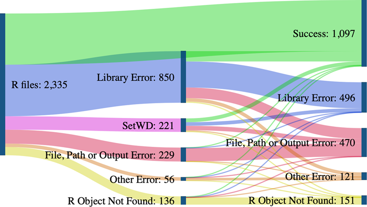

[Trisovic, Lau, Pasquier, et al., 2022](https://doi.org/10.1038/s41597-022-01143-6)

## Reproducibility spectrum

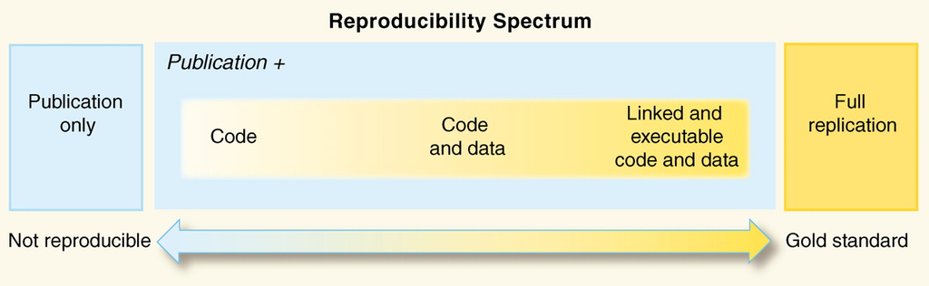

[Peng (2011)](https://doi.org/10.1126/science.1213847)

## Making research reproducible

- reproducible documents
- research compendiums

[figure not shown]

## Reproducible but not replicable

```r
set.seed(1)
run_simulation()
set.seed(2)
run_simulation()
set.seed(3)
```

## Teaching reproducibility

[figure not shown]

[Markup Languages and Reproducible Programming in Statistics](https://www.gerkovink.com/markup/)

## Course aims

Course aims include the development of a publication-ready reproducible research compendium that contains:

- a typeset manuscript following a markup language,
- data and code,
- everything that allows for successful reproduction and reuse of the materials (e.g. a license).

In our course, students are taught various tools and languages, such as Quarto markdown, version control with git, and reproducible environments for `R` with `renv`.

## Full course aims

1. Students develop fundamental knowledge and understanding in the state of the art in statistical markup languages and reproducible programming and development
2. They can determine the most effective markup strategies to address a typesetting problem
3. They can efficiently organize a reproducible programming and development process
4. They can produce repositories up to the standards of international programming and coding conventions and initiatives
5. They can produce publications up to the typesetting standards of international peer-reviewed journals

## Markup languages

[figure not shown]

[figure not shown]

## Version control

[figure not shown]

[figure not shown]

## Licensing

[figure not shown]

[figure not shown]

## Sharing `R` code

[figure not shown]

## Research compendiums

[figure not shown]

[figure not shown]

## Course weeks

1. Markup languages
2. Quarto markdown
3. Version control (with git and GitHub)
4. Reproducible research in statistics
5. Developer portfolios
6. Re-usable R code (with R packages and Shiny)

## Poster

[figure not shown]

# Discussion

## 🗣️

# Outro

## Take aways

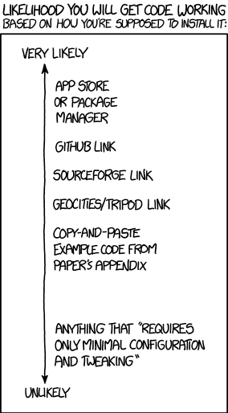

- reproducibility is important
- we should all learn reproducible workflows
- we should teach reproducible workflows

## Thank you!

[figure not shown]

## References

COSiE: Community for Open Science in Education (n.d.). Open Science Community Utrecht. URL: https://openscience-utrecht.com/cosie/

Eglen, S., & Nüst, D. (2024). CODECHECK. URL: https://codecheck.org.uk

FORRT - Framework for Open and Reproducible Research Training (n.d.). URL: https://forrt.org/

Mosteiro P., Oberman H.I. (2026). Markup Languages and Reproducible Programming in Statistics (2024). Course materials. URL: https://www.mlarpis.github.io/markup

The Carpentries (n.d.). The Carpentires. URL: https://carpentries.org/

The Turing Way Community (2025). The Turing Way: A handbook for reproducible, ethical and collaborative research. URL: https://doi.org/10.5281/zenodo.15213042

Utrecht University (2023). Best Practices for Writing Reproducible Code. URL: https://utrechtuniversity.github.io/workshop-computational-reproducibility

Utrecht University (2023). Writing Reproducible Manuscripts in R & Python. URL: https://utrechtuniversity.github.io/workshop-reproducible-manuscripts

## References (cont.)

Utrecht University (2024). The educational model. URL: https://www.uu.nl/en/education/educational-vision/the-educational-model

Utrecht University (2026). Markup languages and reproducible programming in statistics (202000010). Osiris course catalogue. URL: https://osiris-student.uu.nl/#/onderwijscatalogus/extern/cursus?cursuscode=202000010&taal=en&collegejaar=huidig

# Mini lecture: Research Compendiums

## Research compendium

[figure not shown]

## Definition

> A research compendium is a collection of all digital parts of a research project including data, code, texts…

> The collection is created in such a way that reproducing all results is straightforward<sup>1</sup>

> The compendium serves as a means for distributing, managing, and updating the collection<sup>2</sup>
[^1]: [The Turing Way](https://the-turing-way.netlify.app/reproducible-research/compendia)
[^2]: [Gentleman & Temple Lang (2007)](https://doi.org/10.1198/106186007X178663)

## Basic compendium

A basic research compendium is just a folder…

```
compendium/
├── data
│   └── my_data.csv
├── analysis
│   └── my_script.R
├── requirements.txt
└── README.md
```

## (Not so) basic compendium

… but it can become extensive…

```
├── paper/
│   ├── paper.qmd
│   └── references.bib
├── figures/
├── data/
│   ├── raw_data/
│   └── clean_data/
└── templates
    └── journal_template.csl
```

## (Not so) basic compendium

…or even executable!

```
├── _targets.R
├── R/
│   ├── functions_data.R
│   ├── functions_analysis.R
│   ├── functions_visualization.R
└── data/
    └── input_data.csv
```

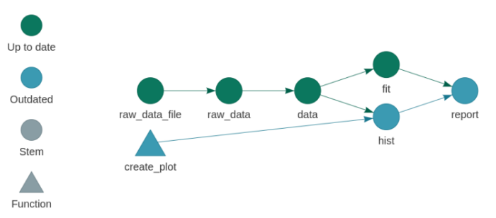

## (Not so) basic compendium

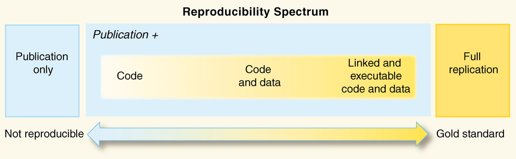

[Peng (2011)](https://doi.org/10.1126/science.1213847)

## Guidelines

- Completeness
- Organization
- Economy
- Transparency
- Documentation
- Access
- Provenance
- Metadata
- Automation
- Review

## In practice

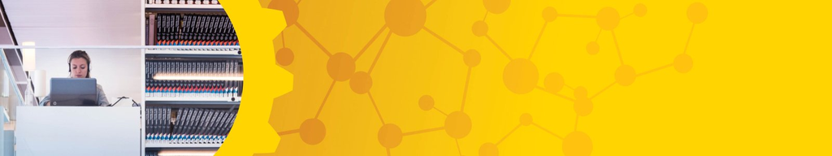

Research Data Management Support workshop:

[**Writing Reproducible Manuscripts in R and Python**](https://utrechtuniversity.github.io/workshop-reproducible-manuscripts/introduction.html)

## Compendium step-by-step

- Think about a good folder structure
  - Split up ‘read-only’, ‘human-generated’, and ‘project-generated’ files
- Create folder structure (main directory and sub directories)
  - Add a landing page in the form of a README document
  - Make the compendium executable (to automatically generate the results; optional)
  - Make the compendium into a git repository (optional)
- Add all files needed for reproducing the results of the project
  - Avoid ‘hard coded’ parameters or human intervention in the execution
- Make the compendium as clean and easy to use as possible
  - Include a citation file and a LICENSE file with info on how it can be used
- Publish your compendium
  - E.g. on Zenodo (optional, more on this in the last course week)

Adapted from [The Turing Way](https://the-turing-way.netlify.app/reproducible-research/compendia#checklist)